# Stats for CogSci2020 submission

Jan 2020

```r
library(here)
library(tidyverse)
library(lme4)
library(RColorBrewer)
```

Read in the data frame that adds density to the variables Josh created. We currently include density in the visualizations but not the statistical analyses.

```r
df <- read_csv(here("code", "data", "df_zapotec_density.csv"))
```

Add variables we’ll need for the analyses.

```r
slab <- function(z) {
  z[!(z %in% c("xlútsǐ", "càrpìntêr",  "msì", "bǎd",  "mtsùu", "wǐt", "dzǐn̲g"))] <-"other"
  z
}

df_mf <- df  %>%
  mutate(is_named = !is.na(folk_specific), logmass = log(mass), logfreq = log(freq)) %>%
  mutate(is_prot = !is.na(folk_specific) & folk_specific==folk_generic)  %>%
  # XXX: should is_compound and name_length be based on specific or generic names?
  mutate(is_compound = grepl('-', folk_specific)) %>%
  mutate(name_length = str_count(folk_specific) - is_compound) %>%
  mutate(logname_length = log(name_length)) %>%
  mutate(clements_group=factor(clements_group))  %>%
  # XXX: include only species for which we have mass and frequency?
  filter(mass > 0 & freq > 0) %>%
  mutate(name=factor(folk_generic)) %>%
  mutate(name=fct_relabel(name, slab)) %>%
  mutate(name=factor(name, levels =  c("dzǐn̲g", "xlútsǐ", "càrpìntêr",  "msì", "bǎd",  "mtsùu", "wǐt", "other"))) %>%
  mutate(e1 = -e1)


# make long data frame for generating figures
df_mf_long <- df_mf %>%
  gather(key='variable', value='val', logmass, logfreq, density)
```

## Prototype plots

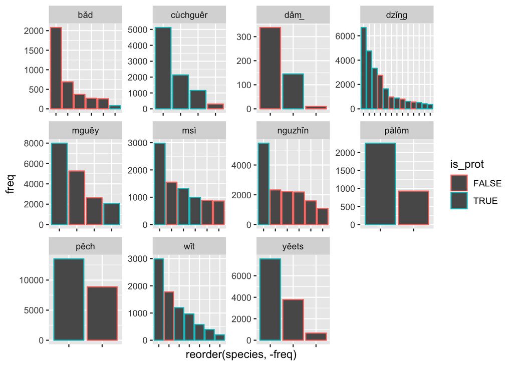

```r
protstatus <- df_mf %>%
  select(folk_generic, is_prot) %>%
  distinct() %>%
  group_by(folk_generic) %>%
  summarize(cnt = n()) %>%
  ungroup() %>%
  filter(cnt>1)

protcats <- inner_join(df_mf, protstatus)

protplot <- protcats %>%
  filter(is_named) %>%
  ggplot(aes(x = reorder(species, -freq), y = freq, color = is_prot)) +
  geom_col() +
  facet_wrap(~folk_generic, scale="free")  +
  theme(axis.text.x=element_blank())

protplot
```

## Morphospace

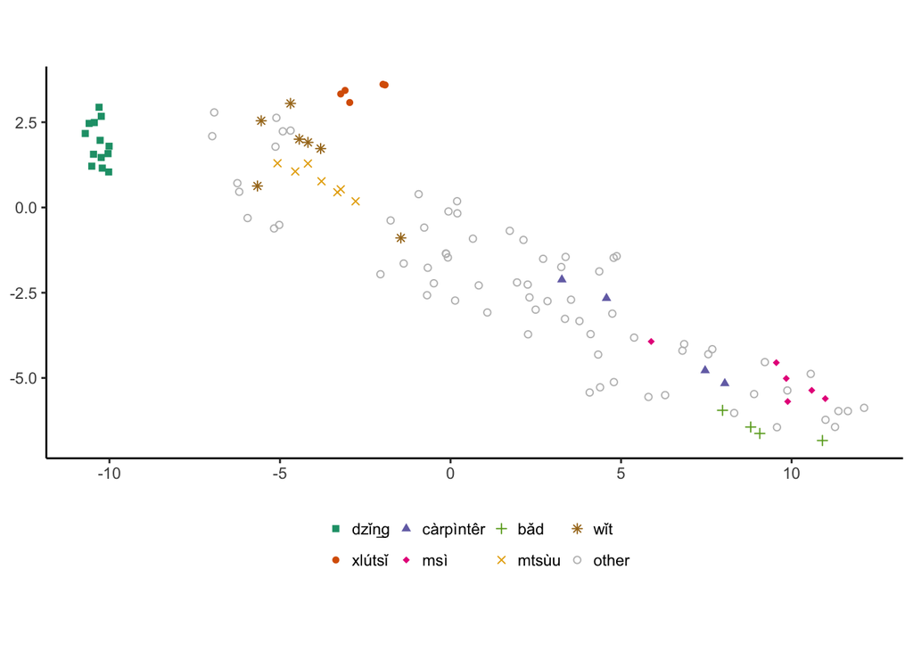

```r
mycolors <- c(brewer.pal(n = 7, name = 'Dark2'), "#BDBDBD")

morphospace_plot <- df_mf %>%
  filter(!is.na(e1) & is_named) %>%
  ggplot(aes(x = e1, y = e2, shape=name, color = name)) +
  #scale_shape_manual(values=1:nlevels(df_mf$plotgen)) +
  scale_shape_manual(values=c(15,16,17,18,3,4,8, 1)) +
  scale_color_manual(values=mycolors) +
  geom_point() +
  coord_fixed() +
  theme_classic() +
  theme(axis.title.x = element_blank(), axis.title.y = element_blank(), legend.title = element_blank()) +
 #theme(plot.margin=grid::unit(c(0,0,0,0), "mm")) +
 theme(legend.position = "bottom", legend.spacing.x = unit(0.1, 'mm'))

morphospace_plot
```

```r
ggsave( here("paper", "figures", "morphospace.png"), width=3.375, units="in")
```

## Named vs Unnamed categories

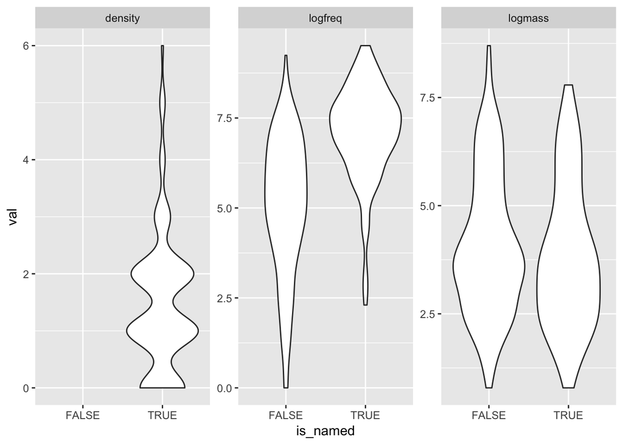

```r
namedvsunnamed_plot <- df_mf_long %>%
  ggplot(aes(x = is_named, y = val)) +
  geom_violin() +
  facet_wrap(~variable, scale="free")
namedvsunnamed_plot
```

```r
logitmodnaming <- glm(
  formula = is_named ~ logfreq + logmass,
  family = binomial,
  data = df_mf)

naming_drop <- drop1(logitmodnaming, test="Chisq")
summary(logitmodnaming)
```

```
##
## Call:
## glm(formula = is_named ~ logfreq + logmass, family = binomial,
##     data = df_mf)
##
## Deviance Residuals:
##      Min        1Q    Median        3Q       Max
## -1.70323  -0.66951  -0.36661  -0.09617   3.08679
##
## Coefficients:
##             Estimate Std. Error z value Pr(>|z|)
## (Intercept) -6.45415    0.69899  -9.234   <2e-16 ***
## logfreq      0.84359    0.09193   9.177   <2e-16 ***
## logmass     -0.03848    0.07171  -0.537    0.592
## ---
## Signif. codes:  0 '***' 0.001 '**' 0.01 '*' 0.05 '.' 0.1 ' ' 1
##
## (Dispersion parameter for binomial family taken to be 1)
##
##     Null deviance: 632.35  on 621  degrees of freedom
## Residual deviance: 492.37  on 619  degrees of freedom
## AIC: 498.37
##
## Number of Fisher Scoring iterations: 6
```

```r
naming_drop
```

```
## Single term deletions
##
## Model:
## is_named ~ logfreq + logmass
##         Df Deviance    AIC     LRT Pr(>Chi)
## <none>       492.37 498.37
## logfreq  1   629.41 633.41 137.042   <2e-16 ***
## logmass  1   492.66 496.66   0.289   0.5907
## ---
## Signif. codes:  0 '***' 0.001 '**' 0.01 '*' 0.05 '.' 0.1 ' ' 1
```

The coefficients suggest that logfreq is a strong predictor (0.84) but that logmass is not (-0.03). The call to `drop1` compares the full model against models that drop one of the predictors. Dropping logfreq means that the model fit gets significantly worse (p < 2e-16), but dropping logmass doesn’t hurt the fit (p = 0.59). The AIC values support this conclusion (dropping logfreq makes the AIC bigger (ie worse), but dropping logmass makes the AIC a little bit better (smaller))

## Lumping analysis

Now we analyze how many other species each named species is lumped with.

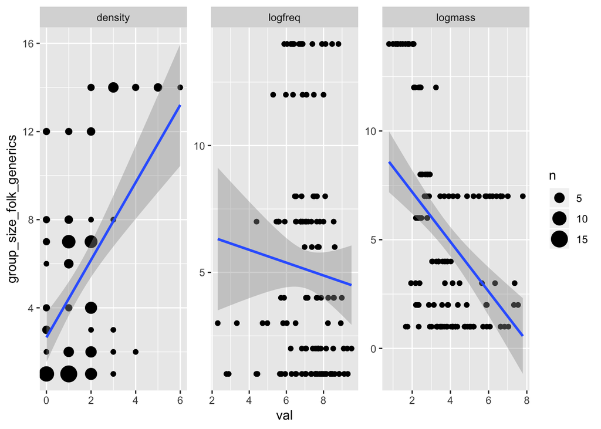

```r
df_named <- df_mf %>%
  filter(is_named) %>%
  mutate(norm_group_size_generic = group_size_folk_generics/group_size_clements)

lumping_plot <- df_mf_long %>%
  filter(is_named) %>%
  ggplot(aes(x = val, y = group_size_folk_generics)) +
  geom_point() +
  geom_count() +
  scale_size_area()+
  geom_smooth(method=lm) +
  facet_wrap(~variable, scales="free")
lumping_plot
```

```r
lmlumping <- lm(
  formula = group_size_folk_generics ~ logfreq + logmass,
  data = df_named)

lumping_drop <- drop1(lmlumping, test="Chisq")
lumping_drop
```

```
## Single term deletions
##
## Model:
## group_size_folk_generics ~ logfreq + logmass
##         Df Sum of Sq    RSS    AIC  Pr(>Chi)
## <none>               1798.4 344.25
## logfreq  1     65.05 1863.4 346.80   0.03295 *
## logmass  1    513.87 2312.2 374.42 1.412e-08 ***
## ---
## Signif. codes:  0 '***' 0.001 '**' 0.01 '*' 0.05 '.' 0.1 ' ' 1
```

```r
summary(lmlumping)
```

```
##
## Call:
## lm(formula = group_size_folk_generics ~ logfreq + logmass, data = df_named)
##
## Residuals:
##     Min      1Q  Median      3Q     Max
## -6.2928 -3.0564 -0.6003  3.5927  6.9854
##
## Coefficients:
##             Estimate Std. Error t value Pr(>|t|)
## (Intercept)  13.6981     2.1525   6.364 3.39e-09 ***
## logfreq      -0.5491     0.2582  -2.126   0.0354 *
## logmass      -1.2288     0.2056  -5.976 2.22e-08 ***
## ---
## Signif. codes:  0 '***' 0.001 '**' 0.01 '*' 0.05 '.' 0.1 ' ' 1
##
## Residual standard error: 3.793 on 125 degrees of freedom
## Multiple R-squared:  0.227,  Adjusted R-squared:  0.2146
## F-statistic: 18.35 on 2 and 125 DF,  p-value: 1.026e-07
```

The coefficients suggest that logmass (-1.22) is a stronger predictor than logfreq (-0.54). Dropping either predictor, however, leads to a model fit that is significantly worse (p values of 0.03 for logfreq and 1e-8 for logmass). AIC values support the same conclusion.

## Compound vs monomial

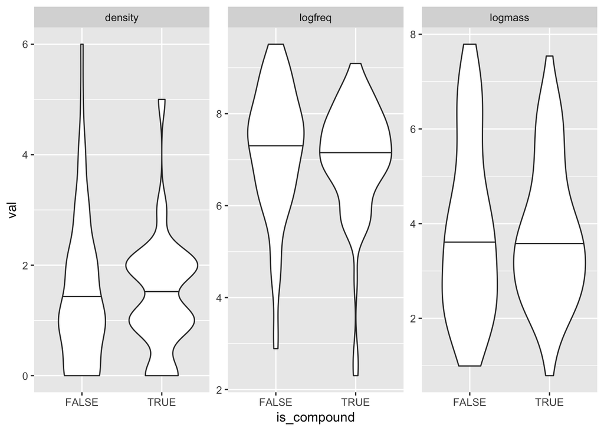

```r
compound_plot <- df_mf_long %>%
  filter(is_named) %>%
  ggplot(aes(x = is_compound, y = val)) +
  geom_violin(draw_quantiles=c(0.5)) +
  facet_wrap(~variable, scale="free")
compound_plot
```

```r
logitmodcompound <- glm(
  formula = is_compound ~ logfreq + logmass,
  family = binomial,
  data = df_named)

compound_drop <- drop1(logitmodcompound, test="Chisq")
compound_drop
```

```
## Single term deletions
##
## Model:
## is_compound ~ logfreq + logmass
##         Df Deviance    AIC     LRT Pr(>Chi)
## <none>       176.84 182.84
## logfreq  1   177.39 181.39 0.55825    0.455
## logmass  1   176.92 180.92 0.08096    0.776
```

```r
summary(logitmodcompound)
```

```
##
## Call:
## glm(formula = is_compound ~ logfreq + logmass, family = binomial,
##     data = df_named)
##
## Deviance Residuals:
##     Min       1Q   Median       3Q      Max
## -1.3598  -1.1769   0.9914   1.1675   1.3020
##
## Coefficients:
##             Estimate Std. Error z value Pr(>|z|)
## (Intercept)  0.87474    1.14623   0.763    0.445
## logfreq     -0.10229    0.13760  -0.743    0.457
## logmass     -0.03093    0.10875  -0.284    0.776
##
## (Dispersion parameter for binomial family taken to be 1)
##
##     Null deviance: 177.41  on 127  degrees of freedom
## Residual deviance: 176.84  on 125  degrees of freedom
## AIC: 182.84
##
## Number of Fisher Scoring iterations: 3
```

## Name length

Suggest not including a figure for this, but just reporting in the text. Effect of frequency goes in opposite way compared to the compound vs monomial analysis (more common things have longer names)

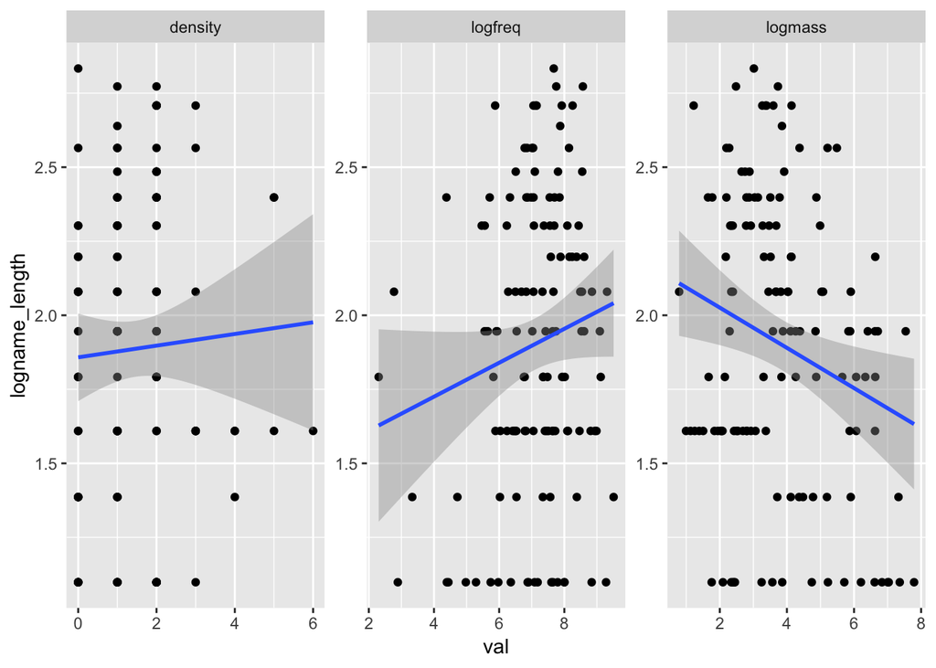

```r
namelength_plot <- df_mf_long %>%
  filter(is_named) %>%
  ggplot(aes(x = val, y = logname_length)) +
  geom_point() +
  geom_smooth(method=lm) +
  facet_wrap(~variable, scale="free")
namelength_plot
```

```r
lmnamelength<- lm(
  formula = logname_length ~ logfreq + logmass,
  data = df_named)

namelength_drop <- drop1(lmnamelength, test="Chisq")
namelength_drop
```

```
## Single term deletions
##
## Model:
## logname_length ~ logfreq + logmass
##         Df Sum of Sq    RSS     AIC Pr(>Chi)
## <none>               29.586 -181.48
## logfreq  1   0.38909 29.975 -181.81  0.19594
## logmass  1   1.28356 30.870 -178.05  0.01973 *
## ---
## Signif. codes:  0 '***' 0.001 '**' 0.01 '*' 0.05 '.' 0.1 ' ' 1
```

```r
summary(lmnamelength)
```

```
##
## Call:
## lm(formula = logname_length ~ logfreq + logmass, data = df_named)
##
## Residuals:
##      Min       1Q   Median       3Q      Max
## -1.00453 -0.40461  0.07665  0.37516  0.85671
##
## Coefficients:
##             Estimate Std. Error t value Pr(>|t|)
## (Intercept)  1.83576    0.27609   6.649 8.22e-10 ***
## logfreq      0.04246    0.03312   1.282   0.2022
## logmass     -0.06141    0.02637  -2.329   0.0215 *
## ---
## Signif. codes:  0 '***' 0.001 '**' 0.01 '*' 0.05 '.' 0.1 ' ' 1
##
## Residual standard error: 0.4865 on 125 degrees of freedom
## Multiple R-squared:  0.06389,    Adjusted R-squared:  0.04892
## F-statistic: 4.266 on 2 and 125 DF,  p-value: 0.01614
```

Coefficients suggest that logfreq (0.04) and logmass (-0.06) are both weak predictors. Dropping logmass significantly impairs model performance (p = 0.02) but dropping logfreq doesn’t (p = 0.2). AIC scores support same conclusion.

## Overall conclusions

#### Frequency

- decent evidence that frequency predicts whether or not a species is named
- only weak evidence that frequency predicts lumping
- no effect of frequency on compound vs monomial or name length

#### Mass

- replicate Hunn’s finding that size predicts lumping (and find that it’s a stronger predictor than frequency)
- only weak evidence that mass predicts anything else

#### Themes for discussion:

- reasons why we don’t see a stronger effect of frequency (discuss wrt theories that do predict frequency effects including functional/utilitarian view, Zipfian view, perhaps others)
- distribution of species in morphospace is an important confound in lumping, compound vs monomial and namelength analyses. Possible that similarity is the big thing: e.g if a species is very similar to many other species than we’d expect to have a high lumping score independent of mass and frequency, and might also expect to have a compound name that reflects the relationship of the species to other similar things.
- Future direction: include similarity as predictor. Use the data in that recent paper (Macroevolutionary convergence connects morphological form to ecological function in birds) to add a “neighborhood density” variable that captures how many other local species a given species is similar to.

## Caveats

This notebook is a quick attempt to generate results we can include in a minimal submittable draft. At some stage we should

- confirm that setting `test=Chisq` in the call to `drop1()` is what we actually want.
- look at residuals and try other kinds of model-checking
- consider mixed effects analyses with random effects for Clemens group